# OA vs. Price Statistical Model

Author

Eric Schares

Oct. 9, 2026

# Overview

The estimand for this analysis is the direct causal effect of Open Access availability (OA%) on a hybrid journal’s subscription price.

> p(Price|do(OA))

Hybrid journals publish a mixture of:

- paywalled articles, which require a subscription to read and
- open articles, made open for anyone to read through payment of an Article Processing Charge (APC)

The exact mixture of open vs. closed content varies by journal and year.

# DAG

The DAG for this analysis is shown in Figure 1 and also saved and available to explore on [dagitty.net](https://dagitty.net/dags.html?id=igp7575y). The direct effect of interest is shown in green, and the red nodes are the minimum adjustment set required to isolate the direct causal effect.

- Publisher (Elsevier, Wiley, etc.)
- Discipline (4 levels)
- number of paywalled articles
- Impact Factor (used as a proxy for prestige)

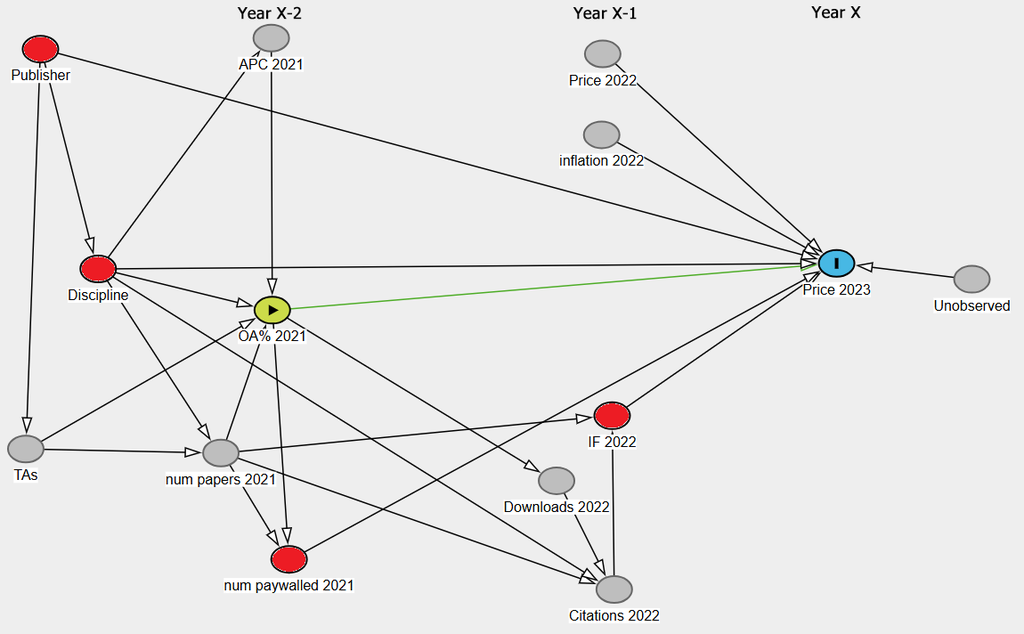

Figure 1: DAG outlining variables thought to influence hybrid journal subscription price

Please note the time factor in the DAG. I have attempted to organize the nodes into columns based on year. Figure 1 shows how the 2023 subscripton price for a journal is determined as an example. In the actual model there will repeated measurements for 7 years on each journal, 2021-2027.

Price in a given year depends on nodes from previous years. In the case of Impact Factor (IF), it is from the previous year. IF is a deterministic function that relies on the number of articles and number of citations. OA% and num articles are from year X-2. This is because subscription prices for a given year (say, 2023) are made available in August or September of the previous year (2022). Since 2022 is not over, the exact mixture of OA% or paywalled articles is not known yet, and thus could not affect the subscription price for 2023. We therefore need to go back another year to use this data.

(I know you are skeptical of lag models, especially using X-2 variables, but in this case I argue that Year-2 is only one time series ago. We don’t have anything closer that would apply.)

The DAG has been inspected by several colleagues both internal and external and presented as a conference poster in Antwerp, Belgium. Small suggestions were made but overall the reception was good. I am reasonably confident in this adjustment set.

# Analysis

Remember to clean and refresh Environment

## Load libraries

```r
library(tidyverse)
library(rethinking)
#library(marginaleffects)  # for interpreting model results
library(ggridges)         # for ridge plots
```

# Simulate synthetic journals

Currently, I am simulating synthetic data for OA vs. Price with:

- 2x2 matrix of alphas for 2 Publisher and 2 Discipline levels $\alpha_{pd}$ (like the UCB Admission example, SR 2026 A09 41:00)
- Journal specific intercept $\alpha_j$
- Number of paywalled articles
- IF
- Price as a lognormal distribution in the likelihood
- standardized predictor variables OA, num_art, and IF
- multilevel structure: each journal is measured 7 times, once per year

## Will still need to add:

- 2 more Discipline levels for 4 total
- a beta for each Pub_Disc separately? 3 betas * 8 Pub_Disc levels (2x4) = 24 beta coefficients?? Maybe just each publisher separately
- do I standardize the outcome variable, price?
- standardize the combined alpha too? Then how would I get up to values like $3,000? Betas will be huge

```r
sim_journals_lognormal_multilevel <- function(
    J = 50,             # number of journals
    num_years = 7,    # number of years per journal

                    # P1D1, P1D2, P2D1, P2D2;
                    # Pub 1->2 -1000; Disc 1->2 +500
    a_pub = c(log(2000), log(2500), log(1000), log(1500)),   # Publisher Discipline baselines

    #inflation = 0.03,       # persistent 3% YoY inflation
    #b_OA = -0.05,       # -5% price shift with 1 SD increase in OA
    b_articles = 0.15,  # +15% price shift with 1 SD increase in volume
    b_IF = 0.25,        # 25% price increase with 1SD increase of IF
    sigma = 0.2
    ) {

  #### Individual Journal properties ####

  Publisher_j <- rbern(J, 0.5) + 1         # 2 levels, 1 or 2

  # DAG shows Discipline depends on Publisher
  prob_disc   <- ifelse(Publisher_j == 1, 0.6, 0.3)
  Disc_j      <- rbern(J, prob_disc) + 1   # 2 levels, 1 or 2


  # Combined index for alpha 1-4: 1=(P1,D1), 2=(P1,D2), 3=(P2,D1), 4=(P2,D2)
  Pub_Disc_j  <- ifelse(Publisher_j == 1,
                     ifelse(Disc_j == 1, 1, 2),
                     ifelse(Disc_j == 1, 3, 4))

  # Random variation in journals, a specific offset
  a_journal_j <- rnorm(J, 0, 0.5)   #0.7, 0.25, -0.12, etc.


  #### Journals across years ####

  journal_id <- rep(1:J, each = num_years)     # repeats in blocks: 1, 1, 1, 2, 2, 2, etc
  year       <- rep(1:num_years, times = J)    # repeats in series: 1, 2, 3, 1, 2, 3
  N          <- J * num_years                  # rows

  # Repeat journal static characteristics across years
  Publisher <- Publisher_j[journal_id]         # using journal_id repeats the descriptor in blocks
  Disc      <- Disc_j[journal_id]
  Pub_Disc  <- Pub_Disc_j[journal_id]
  a_journal <- a_journal_j[journal_id]


  #### Time varying predictors, N observations

  # OA depends on Discipline (1 or 2)
  OA_raw  <- rnorm(N, ifelse(Disc == 1, 20, 30), 10)
  OA_raw  <- pmax(0, OA_raw)   # set floor to 0%

  # Articles depends on OA%
  art_raw <- rnorm(N, 1200, 500)
  art_raw <- pmax(10, art_raw * ( (100 - OA_raw) / 100) )  # set floor to 10 articles

  # IF depends on nothing, use a LogNormal distribution
  IF_raw <- rlnorm(N, meanlog = log(2.5), sdlog = 0.8)
  log_IF <- log(IF_raw)      # approx normal with mean log(2.5)

  # Standardize predictors across entire dataset, not just within each year!
  z_OA        <- standardize(OA_raw)
  z_articles  <- standardize(art_raw)
  z_IF        <- standardize(log_IF)

  # OA effect varies by publisher
  b_OA = c(-0.05, 0.05)       # -5% price shift with 1 SD increase in OA


  # use standardized predictors
  log_mu <- a_pub[Pub_Disc] +
            a_journal +
            b_OA[Publisher] * z_OA +
            b_articles * z_articles +
            b_IF * z_IF
            #rnorm(N, 0, 1)


  Price <- exp(log_mu)                    # wait, do we take exp(log_mu) exactly,
  #Price <- rlnorm(N, log_mu, sigma)      # or a draw from a LogNormal with that mean??
                                          # would add a whole nother level of variation

  data.frame(journal_id, a_journal, year, Publisher, Disc, Pub_Disc, sigma, OA_raw, z_OA, art_raw, z_articles, IF_raw, log_IF, z_IF, log_mu, Price)

}


dat <- sim_journals_lognormal_multilevel( )

# If the price of a journal should only go up year over year:
dat <- dat |>
  group_by(journal_id) |>
  mutate(
    adjusted_price = Reduce(
      f = function(prev, curr) max(curr, prev * 1.03),   # compare current price to 3% inflation over last year's
      x = Price,
      accumulate = TRUE
    )
  ) |>
  ungroup()

head(dat)
```

```
# A tibble: 6 × 17
  journal_id a_journal  year Publisher  Disc Pub_Disc sigma OA_raw    z_OA
       <int>     <dbl> <int>     <dbl> <dbl>    <dbl> <dbl>  <dbl>   <dbl>
1          1   -0.0714     1         2     1        3   0.2   13.9 -0.925
2          1   -0.0714     2         2     1        3   0.2   19.4 -0.439
3          1   -0.0714     3         2     1        3   0.2   23.4 -0.0781
4          1   -0.0714     4         2     1        3   0.2   16.7 -0.674
5          1   -0.0714     5         2     1        3   0.2   10.1 -1.27
6          1   -0.0714     6         2     1        3   0.2   10.3 -1.24
# ℹ 8 more variables: art_raw <dbl>, z_articles <dbl>, IF_raw <dbl>,
#   log_IF <dbl>, z_IF <dbl>, log_mu <dbl>, Price <dbl>, adjusted_price <dbl>
```

Summarize it

```r
dat |>
  summarize(n_rows = n(),
            n_journals = n() / 7,
            meanOA = mean(OA_raw),
            meanPrice = mean(Price),
            meanArticles = mean(art_raw),
            minArticles = min(art_raw),
            maxArticles = max(art_raw),
            meanIF = mean(IF_raw),
            .by = c(Publisher, Disc, Pub_Disc)) |>
  arrange(Pub_Disc)
```

```
# A tibble: 4 × 11
  Publisher  Disc Pub_Disc n_rows n_journals meanOA meanPrice meanArticles
      <dbl> <dbl>    <dbl>  <int>      <dbl>  <dbl>     <dbl>        <dbl>
1         1     1        1     91         13   21.0     2108.         948.
2         1     2        2     98         14   30.7     2466.         842.
3         2     1        3    140         20   22.0     1321.         957.
4         2     2        4     21          3   24.0     1479.         893.
# ℹ 3 more variables: minArticles <dbl>, maxArticles <dbl>, meanIF <dbl>
```

```r
# ggplot(data.frame(Publisher, Disc), aes(x = Publisher, y = Disc)) +
#   geom_point()
```

Graph it

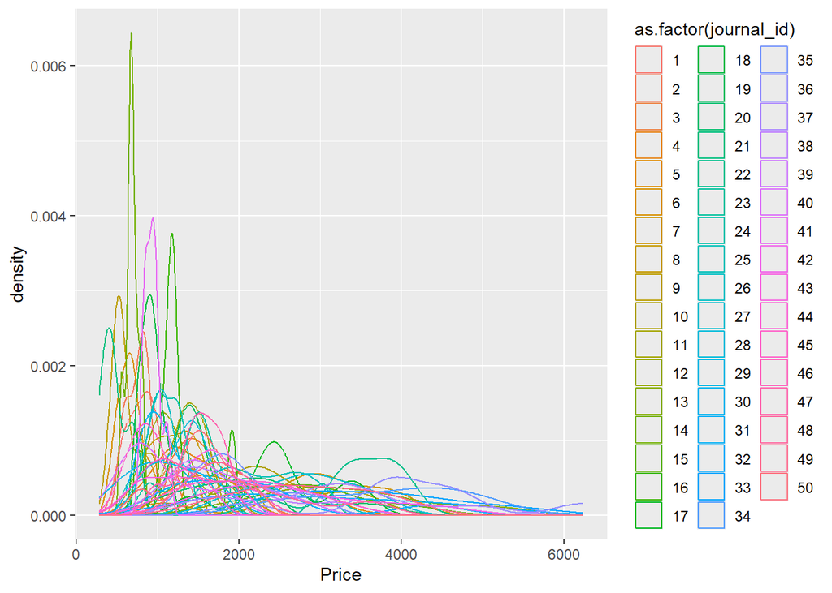

```r
dat |>
  ggplot(aes(x = Price)) +
    geom_density(aes(colour = as.factor(journal_id)))
```

```r
  #facet_wrap(~journal_id)
```

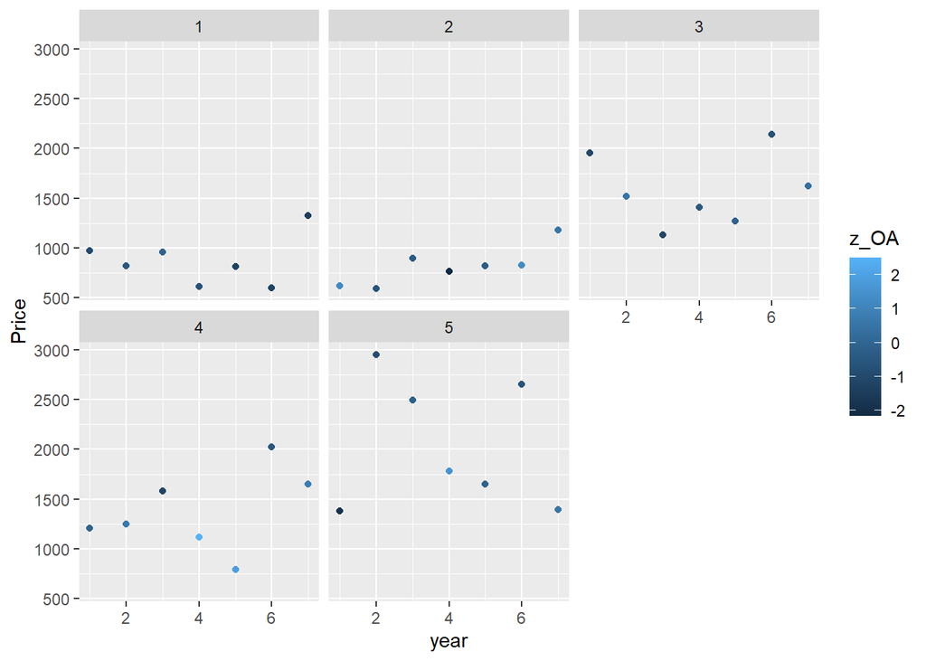

```r
# First 5 journals
dat |>
  slice_head(n=7*5) |>
  ggplot(aes(x = year, y = Price)) +
    geom_point(aes(colour = z_OA)) +
  facet_wrap(~journal_id)
```

# Prior predictive distribution

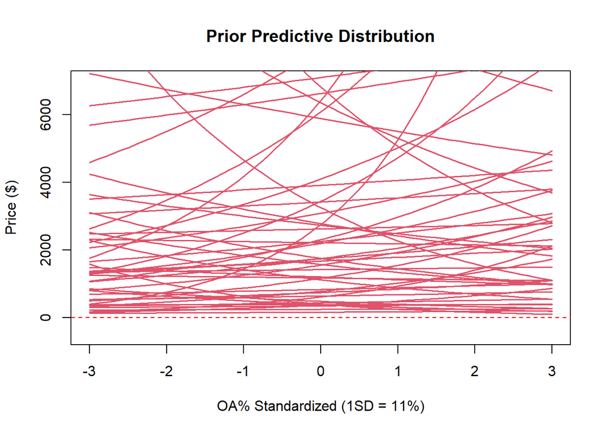

```r
# Think about plausible ranges of each parameter

n <- 1e3

a_pub_disc  <- rnorm(n, 7.5, 1)    # Publisher intercept at mean OA (20%), mean num articles (1000), mean IF (2.5)

a_journal_j <- rnorm(n, 0, 0.5)    #95% -1 to 1

# sd(dat$OA_raw)    # 11
# sd(dat$art_raw)   # 400
# sd(dat$IF_raw)    # 1.5
#
# mean(dat$OA_raw)   # 20
# mean(dat$art_raw)  # 1000
# mean(dat$IF_raw)   # 2.5
# mean(dat$Price)    # 1500

# 0, 0.2 means 95% between -40% and +40%
b_OA   <- rnorm(n, 0, 0.2)       # OA effect, $ change per 1SD in OA
b_art  <- rnorm(n, 0, 0.2)       # volume effect, $ change per 1SD in articles
b_IF   <- rnorm(n, 0, 0.2)


OA_seq <- seq(-3, 3, length.out = 60)
art_ref <- 0     # taking average article
IF_ref  <- 0     # Impact Factor at average


plot(NULL, xlim = c(-3, 3),
           ylim = c(-500, 7000),
           xlab = "OA% Standardized (1SD = 11%)", ylab = "Price ($)", main = "Prior Predictive Distribution")

for (j in 1:50) {
  log_mu <- a_pub_disc[j] +
        a_journal_j[j] +
        b_OA[j] * OA_seq +
        b_art[j] * art_ref +  # standardized priors, get zero'd out
        b_IF[j] * IF_ref

  lines( OA_seq, exp(log_mu),
         lwd = 1.5, col = 2)

}

abline(h = 0, lty = 2, col = "red")
```

# Run Model

Run the model to estimate the parameters. Converted alpha model to a matrix of [Pub, Disc]. Requires some downstream edits to process.

Add multi-level priors on the alpha intercept

Add journal parameter to remember that we have repeated measurements on each journal

```r
m4.10 <- ulam(
  alist(
    #adjusted_price ~ dlnorm(log(mu), sigma),     # for price that only goes up
    Price ~ dlnorm(mu, sigma),

    mu <- a[Publisher, Disc] +
          a_journal_est[journal_id] +
          b_OA[Publisher] * z_OA +
          b_articles * z_articles +
          b_IF * z_IF,

    matrix[Publisher, Disc]:a ~ dnorm(abar, zigma),

    abar ~ dnorm(7.5, 1),    # Global intercept at mean OA, articles, and IF, exp(7.5) = $1800
    zigma ~ dexp(1),

    a_journal_est[journal_id] ~ dnorm(0, 0.5),
    b_OA[Publisher] ~ dnorm(0, 0.2),                    # $ change per 1 SD OA
    b_articles ~ dnorm(0, 0.2),              # $ change per 1 SD articles
    b_IF ~ dlnorm(0, 0.2),                   # $ change per 1 SD in IF

    sigma ~ dexp(1)

  ), data=dat, chains=4, cores=4, log_lik = TRUE
)
```

```
Running MCMC with 4 parallel chains, with 1 thread(s) per chain...

Chain 1 Iteration:   1 / 1000 [  0%]  (Warmup)
Chain 1 Iteration: 100 / 1000 [ 10%]  (Warmup)
Chain 1 Iteration: 200 / 1000 [ 20%]  (Warmup)
Chain 2 Iteration:   1 / 1000 [  0%]  (Warmup)
Chain 2 Iteration: 100 / 1000 [ 10%]  (Warmup)
```

```
Chain 2 Informational Message: The current Metropolis proposal is about to be rejected because of the following issue:
```

[output not shown]

[output not shown]

[output not shown]

```
Chain 2
```

```
Chain 3 Iteration:   1 / 1000 [  0%]  (Warmup)
```

```
Chain 3 Informational Message: The current Metropolis proposal is about to be rejected because of the following issue:
```

[output not shown]

[output not shown]

[output not shown]

```
Chain 3
```

[output not shown]

## Check parameters

```r
precis(m4.10, depth = 3)
```

```
                         mean         sd        5.5%       94.5%      rhat
a[1,1]             7.46125526 0.14117305  7.23794595  7.68510084 1.0443447
a[2,1]             7.09375192 0.10974816  6.92218566  7.27039861 1.0465909
a[1,2]             7.70006898 0.13127123  7.49399163  7.90757034 1.0271132
a[2,2]             7.28289092 0.22790273  6.91243624  7.65383844 1.0034915
abar               7.38962385 0.22016444  7.04555780  7.72736313 1.0083551
zigma              0.42108193 0.26312554  0.16179400  0.90766097 1.0057313
a_journal_est[1]  -0.24494395 0.13257991 -0.45863170 -0.03562000 1.0290663
a_journal_est[2]  -0.69955343 0.15781560 -0.93953079 -0.44157224 1.0368951
a_journal_est[3]   0.17353183 0.13216277 -0.03735065  0.37834915 1.0298504
a_journal_est[4]  -0.38333379 0.14707175 -0.62741794 -0.15035346 1.0209011
a_journal_est[5]   0.12604098 0.23487097 -0.25944190  0.50237465 1.0024261
a_journal_est[6]  -0.49864309 0.13294435 -0.71759373 -0.29040226 1.0286665
a_journal_est[7]   0.21897026 0.15965698 -0.03807338  0.46762668 1.0337905
a_journal_est[8]  -0.12482773 0.13076278 -0.33077372  0.08629895 1.0283627
a_journal_est[9]  -0.78234917 0.13106240 -0.99811052 -0.57363066 1.0296519
a_journal_est[10]  0.33795226 0.14769150  0.09732148  0.56512709 1.0230770
a_journal_est[11] -0.25287046 0.15634666 -0.50575204 -0.01175085 1.0355076
a_journal_est[12]  0.18114882 0.13142447 -0.03630760  0.39038665 1.0342148
a_journal_est[13]  0.32565273 0.14919192  0.08493289  0.55505912 1.0174288
a_journal_est[14] -0.38882166 0.13284420 -0.61096841 -0.18116735 1.0337040
a_journal_est[15]  0.15366285 0.14787737 -0.08065047  0.38521391 1.0242020
a_journal_est[16]  0.02918672 0.12979135 -0.18158627  0.22631471 1.0279667
a_journal_est[17]  0.20862456 0.14808656 -0.03108874  0.44907961 1.0217165
a_journal_est[18] -0.62635620 0.15788320 -0.87506650 -0.37331661 1.0375018
a_journal_est[19] -0.01733935 0.15770708 -0.25848268  0.23916501 1.0366373
a_journal_est[20]  0.35633906 0.12922244  0.15030353  0.56071979 1.0337689
a_journal_est[21] -0.84058181 0.12911057 -1.04390355 -0.63718160 1.0330857
a_journal_est[22]  1.13398596 0.13159557  0.91331041  1.34069724 1.0289766
a_journal_est[23] -0.08425647 0.15687598 -0.32669872  0.17248992 1.0333179
a_journal_est[24] -0.24833310 0.12889667 -0.45576704 -0.04568504 1.0272541
a_journal_est[25] -0.06764514 0.14941813 -0.30433792  0.16729630 1.0210040
a_journal_est[26]  0.02665899 0.13237940 -0.18732666  0.23586714 1.0350371
a_journal_est[27]  0.19816840 0.15945511 -0.04214779  0.46095087 1.0359577
a_journal_est[28]  0.01722923 0.23546560 -0.36537502  0.40954464 1.0030695
a_journal_est[29] -0.16023585 0.13301741 -0.37755377  0.05190249 1.0344142
a_journal_est[30] -0.40232894 0.23683133 -0.77973296 -0.01821257 1.0048540
a_journal_est[31]  0.50105045 0.15726888  0.25205806  0.75114316 1.0375116
a_journal_est[32] -0.01540464 0.15696949 -0.26916555  0.23198877 1.0368040
a_journal_est[33]  0.56944363 0.15722183  0.32133518  0.81997215 1.0353682
```

[output cut: 67 more lines]

```
a_journal_est[40]  147.2076
a_journal_est[41]  204.8154
a_journal_est[42]  179.7832
a_journal_est[43]  168.8217
a_journal_est[44]  184.7459
a_journal_est[45]  151.4058
a_journal_est[46]  169.1922
a_journal_est[47]  201.9263
a_journal_est[48]  152.5547
a_journal_est[49]  191.3374
a_journal_est[50]  197.2149
b_OA[1]           1304.9052
b_OA[2]           1488.4060
b_articles        1346.3726
b_IF              1725.9805
```